# D207 Exploratory Data Analysis

## Performance Assessment

### A1: Analysis Question

Does churn vary significantly among customers of differing contract lengths?

### A2: Benefits of Analysis to Stakeholders

In this analysis, I will be looking at whether contract length has an impact on customer churn. Understanding what factors affect customer churn is of critical importance to the organization. This information can be used to help predict churn in the future and to create strategies for better customer retention.

### A3: Data Used for Analysis

For this analysis, I will be using the churn and contract columns. The churn column contains either "Yes" or "No" indicating whether a customer ended their contract that month. The contract column contains the values "Month-to-month", "Two Year", and "One Year". These values indicate the length of each customer's contract.

### B1: Analysis Code

```python
# import libraries for analysis
import pandas as pd
from scipy import stats
```

```python
df = pd.read_csv("churn_clean.csv", na_values="NA", keep_default_na=False)
```

```python
#make a copy of data frame for analysis
churn = df.copy()
#set column names to all lower case
churn.columns = churn.columns.str.lower()
```

```python
#create table for analysis
table = pd.crosstab(churn['churn'], churn['contract'])
print(table)
```

```
contract  Month-to-month  One year  Two Year
churn
No                  3422      1795      2133
Yes                 2034       307       309
```

```python
#perform chi-square test
chi_test = stats.chi2_contingency(table)
```

### B2: Code Output

```python
print("Chi-Square Statistic:", chi_test[0], '\n')
print("P Value:", chi_test[1], '\n')
print("Degrees of Freedom:", chi_test[2], '\n')
print('Expected Frequencies:\n', chi_test[3])
```

```
Chi-Square Statistic: 718.5915805949758

P Value: 9.116348157571405e-157

Degrees of Freedom: 2

Expected Frequencies:
 [[4010.16 1544.97 1794.87]
 [1445.84  557.03  647.13]]
```

### B3: Justification for Chosen Technique

For this analysis, I chose to use a chi-square test. The variables I used, churn and contract, are both qualitative variables and contain nominal data. T-test and ANOVA both require quantitative data so they were not suitable for this analysis. Chi-square on the other hand is used for determining the whether there is a significant association between qualitative variables making it the appropriate choice for this analysis.

### C: Univariate Statistics

#### Income Statistics:

The income variable has a right skewed distribution. This can be seen in the histogram in section C1. The distribution of the values in the graph are not symmetrical and skew heavily to the left edge of the graph. We can also observe the skewed nature of the data by looking at the mean and median. The average income for our customers is 39,806, but the median income is 33,170. This large difference implies a right skewed distribution because the median is significantly lower than the mean implying that most of the data falls to the left of the mean.

```python
#statistics for income column
print('Income Statistics\n',
      churn['income'].describe())
```

```
Income Statistics
 count     10000.000000
mean      39806.926771
std       28199.916702
min         348.670000
25%       19224.717500
50%       33170.605000
75%       53246.170000
max      258900.700000
Name: income, dtype: float64
```

#### Monthly Charge Statistics:

The monthly charge variable has a normal distribution. This can be seen by observing the symmetrical shape of the histogram in section C1 and observing the mean and median values. The average monthly charge for customers is 172, which is only slightly larger than the median of 167.

```python
#statistics for monthly charge column
print('Monthly Charge Statistics\n',
      churn['monthlycharge'].describe())
```

```
Monthly Charge Statistics
 count    10000.000000
mean       172.624816
std         42.943094
min         79.978860
25%        139.979239
50%        167.484700
75%        200.734725
max        290.160419
Name: monthlycharge, dtype: float64
```

#### Item 1 Statistics

The item1 column has a normal distribution which can be seen by the symmetrical shape of the histogram in section C1. The variable has a mode of 3 with 4 only having slightly fewer values.

```python
#statistics for item1 column
print('Importance of Timely Responses to Customers\n',
      churn['item1'].value_counts())
```

```
Importance of Timely Responses to Customers
 item1
3    3448
4    3358
2    1393
5    1359
1     224
6     199
7      19
Name: count, dtype: int64
```

#### Item 2 Statistics

The item2 column has a normal distribution which can be seen by the symmetrical shape of the histogram in section C1. The variable has a mode of 3 with 4 only having slightly fewer values.

```python
#statistics for item2 column
print('Importance of Timely Fixes to Customers\n',
      churn['item2'].value_counts())
```

```
Importance of Timely Fixes to Customers
 item2
3    3415
4    3412
5    1368
2    1360
1     217
6     215
7      13
Name: count, dtype: int64
```

### C1: Visualization

```python
#import visualization packages
import matplotlib.pyplot as plt
import seaborn as sns
```

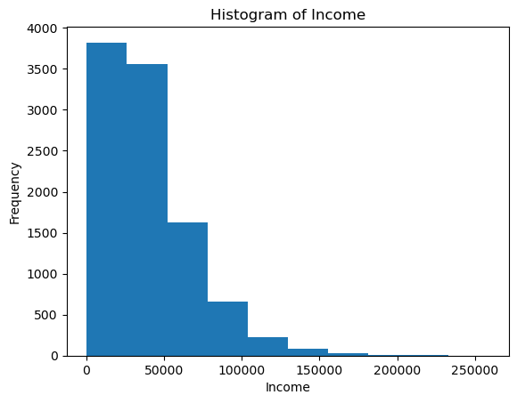

```python
#histogram of income column
churn['income'].plot(kind='hist')
plt.title('Histogram of Income')
plt.xlabel('Income')
```

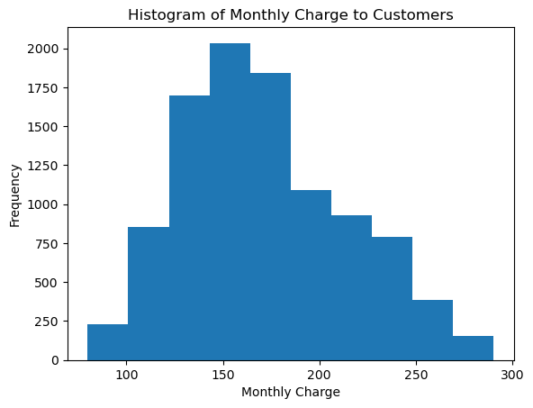

```python
#histogram of monthly charge column
churn['monthlycharge'].plot(kind='hist')
plt.title('Histogram of Monthly Charge to Customers')
plt.xlabel('Monthly Charge')
```

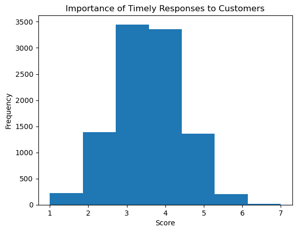

```python
#histogram of item1 column
churn['item1'].plot(kind='hist', bins=7)
plt.title('Importance of Timely Responses to Customers')
plt.xlabel('Score')
```

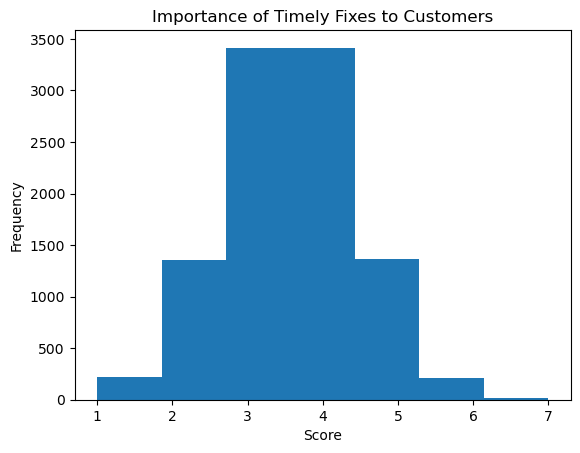

```python
#histogram of item2 column
churn['item2'].plot(kind='hist', bins=7)
plt.title('Importance of Timely Fixes to Customers')
plt.xlabel('Score')
```

### D: Bivariate Statistics

#### Churn and Monthly Charge Statistics

The distribution of monthly charge for customers who ended and continued their contracts are normal. We can see this by looking at the density plot for each group in section D1. The plots for both groups are symmetrical. We can also observe this by looking at the mean and median for each group. Customers who ended their contracts have an average monthly charge of 199 and a median of 200. Customers who didn't end their contracts have an average monthly charge of 163 and a median of 159. It also shows that the average monthly for customers who ended their contract is much higher than it is for those who didn't end their contract.

```python
yes_churn = churn[churn['churn']=='Yes']
no_churn = churn[churn['churn']=='No']

#statistics for each group
print('Monthly Charge Statistics for Departing Customers\n',
      yes_churn['monthlycharge'].describe(), '\n')
print('Monthly Charge Statistics for Remaining Customers\n',
      no_churn['monthlycharge'].describe())
```

```
Monthly Charge Statistics for Departing Customers
 count    2650.000000
mean      199.295175
std        41.268191
min        92.455140
25%       167.484705
50%       200.118500
75%       232.641455
max       290.160419
Name: monthlycharge, dtype: float64

Monthly Charge Statistics for Remaining Customers
 count    7350.000000
mean      163.008973
std        39.322148
min        79.978860
25%       137.439154
50%       159.964200
75%       184.978458
max       290.160400
Name: monthlycharge, dtype: float64
```

#### Income and Contract Statistics

The income distribution of customers for each contract type appear to be the same. We can observe this in the density plot in section D1. The plots for each contract type are right skewed with the peak of each line being around the same place. We can confirm this by looking at the mean and median for each group. All three groups have an average income around 39,000 and a median around 33,000.

```python
monthly = churn[churn['contract']=='Month-to-month']
one_year = churn[churn['contract']=='One year']
two_year = churn[churn['contract']=='Two Year']

#statistics for each group
print('Income Statistics for Month-to-Month Customers\n',
     monthly['income'].describe(), '\n')
print('Income Statistics for One Year Contract Customers\n',
     one_year['income'].describe(), '\n')
print('Income Statistics for Two Year Contract Customers\n',
     two_year['income'].describe())
```

```
Income Statistics for Month-to-Month Customers
 count      5456.000000
mean      39848.090894
std       28477.722324
min         348.670000
25%       18924.657500
50%       33205.895000
75%       53259.460000
max      256998.400000
Name: income, dtype: float64

Income Statistics for One Year Contract Customers
 count      2102.000000
mean      39928.537740
std       27943.259724
min         630.240000
25%       19954.797500
50%       32817.205000
75%       53863.562500
max      167846.000000
Name: income, dtype: float64

Income Statistics for Two Year Contract Customers
 count      2442.000000
mean      39610.277420
std       27803.728759
min         644.320000
25%       19288.840000
50%       33365.400000
75%       52708.910000
max      258900.700000
Name: income, dtype: float64
```

### D1: Visualization

```python
# remove future warning messages [In-Text Citation: (Henley, 2023)]
import warnings
warnings.simplefilter(action='ignore', category=FutureWarning)
```

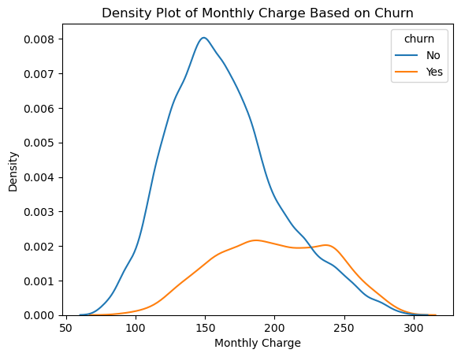

```python
#density plot of monthly charge based on churn
sns.kdeplot(data=churn, x='monthlycharge', hue='churn')
plt.title('Density Plot of Monthly Charge Based on Churn')
plt.xlabel('Monthly Charge')
```

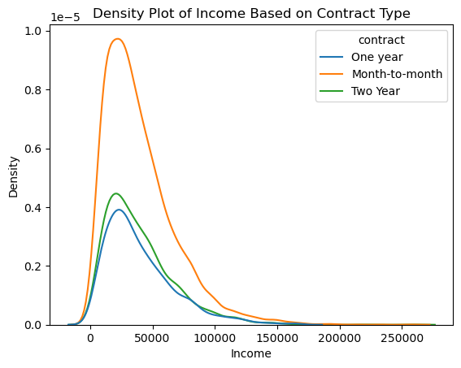

```python
#density plot of income and contract type
sns.kdeplot(data=churn, x='income', hue='contract')
plt.title('Density Plot of Income Based on Contract Type')
plt.xlabel('Income')
```

### E1: Results of Hypothesis Test Discussion

The purpose of this analysis was to determine if the observed difference in churn of customers of different contract types was statistically significant. Looking at the table generated for the analysis, we see that customers with monthly contracts have significantly higher churn than customers with one year and two year contracts. The null hypothesis for this analysis is that this observed difference is not statistically significant. The alternative hypothesis would be that the observed difference is significant and that a realtionship exists between the variables. The analysis yielded a p value of 9.11e-157 which is much lower than our alpha of 0.05. Therefore, we can reject the null hypothesis and say that the observed difference between the variables is statistically significant.

### E2: Limitations of Analysis

The chi-square analysis can only tell us if the observed difference is statistically significant. It does not establish causation. For this analysis, we can only say that churn and contract type are related. We can not say that a customers contract type will cause them to leave.

Another limitation to chi-square is that it can only be used with categorical variables. It cannot be used with quantitative data.

### E3: Recommendations

The next step for this analysis would be to further investigate the relationship between contract type and churn by looking at other variables and how they differ between contract types to establish the cause of the relationship between contract type and churn.

### F: Panopto Video

https://wgu.hosted.panopto.com/Panopto/Pages/Viewer.aspx?id=98033910-da78-4cf1-badd-b0d2010ae898

### G: Code References

Hanley, P. (2023, July 10). *Ignoring FutureWarnings in Python pandas*. Stack Overflow. https://stackoverflow.com/questions/67797816/ignoring-futurewarnings-in-python-pandas

### H: Sources

No Sources Used